# DATASCI 385 - Experimental Methods

Lecture 17 - Texts for Discussion about Interference and Spillovers

Danilo Freire

danilo.freire@emory.edu

Department of Data and Decision Sciences  
Emory University

# Olá! How are you doing? 😊

# Brief recap 📚

## Brief recap 📚

- Spillovers are a common problem in social science research
- They can be positive or negative, and they can be modelled explicitly in our analysis
- There are several methods to deal with spillovers, such as multi-level designs, within-subject designs, repeated-measures experiments, and waitlist designs
- Each design has its advantages and disadvantages, and the choice of design should be based on the research question and the context
- You can use [DeclareDesign](https://declaredesign.org/r/designlibrary/) to simulate spillover designs and pretest–posttest designs
- The statistical analysis of waitlist designs is a little tricky, but you can use the [swCRTdesign](https://cran.r-project.org/web/packages/swCRTdesign/index.html) package in R to help you with that

[figure not shown]

Source: [Forbes (2022)](https://www.forbes.com/councils/forbesbusinesscouncil/2022/10/14/network-effects-how-your-connections-matter/)

# Today’s plan 📅

## Interference and spillovers

- Three readings for today:
  - [Centola (2010)](https://www.science.org/doi/abs/10.1126/science.1185231): “The Spread of Behavior in an Online Social Network Experiment”
  - [Paluck et al. (2016)](https://www.pnas.org/doi/abs/10.1073/pnas.1514483113): “Changing climates of conflict: A social network experiment in 56 schools”
  - [Gerber and Green (2000)](https://doi.org/10.2307/2585837): “The Effects of Canvassing, Telephone Calls, and Direct Mail on Voter Turnout: A Field Experiment” (if time permits)

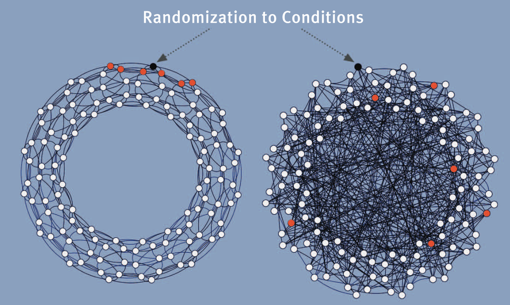

Source: [Centola (2010)](https://www.science.org/doi/abs/10.1126/science.1185231)

# Discussion 💬

## Centola (2010)

### The Spread of Behavior in an Online Social Network Experiment

- How do social networks affect the spread of behaviour?
- Do tight-knit or loose-knit networks facilitate the spread of social behaviour?
  - Clustered networks can spread behaviour more quickly than random networks because they have more connections and reinforce each other
  - In contrast, weak ties can spread behaviour more widely than strong ties because they connect different clusters
  - “Strength of weak ties” (Granovetter, 1973): paradoxical idea that weak ties can be more valuable than strong ties in spreading information

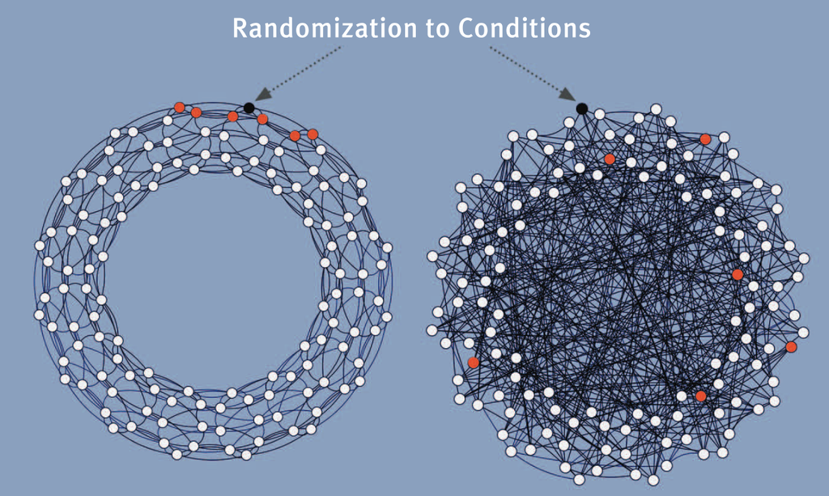

Source: [Centola (2010)](https://www.science.org/doi/abs/10.1126/science.1185231)

- Which one do you think is more important?
  - If you want to spread rumours?
  - If you want to spread a new product?

## Research design

- Can you easily manipulate the network structure?
- Not always, but you can use random assignment to create different network structures
- The author created an online health community with 1528 participants recruited from internet forums
- All participants were anonymous and were partnered with “health buddies” to share information about health behaviours
- Participants made decisions about whether or not to adopt a health behaviour based on the adoption patterns of their health buddies
- The health behaviour used for this study was the decision to register for an Internet-based health forum
- What do you think of this design so far?

## Research design

- The author assigned participants to one of two network structures:
  - Clustered networks with highly connected participants
  - Random networks with weak ties between participants
- Treatment was assigned before the experiment started and participants were not aware of their network structure
- The author claims the design is better than observational studies because it eliminates confounding variables such as
  - Personality traits
  - Geographic location
  - Advertising and pricing
  - Changes in the networks over time
- Can you do the same with massive data from social media?

## Research design

- Diffusion was initiated by selecting a random “seed node”, which sent signals to its network neighbours encouraging them to adopt a health-related behaviour
- Every time a participant adopted the behaviour (i.e., registered for the health forum), messages were sent to their health buddies inviting them to adopt
- If a participant had multiple health buddies who adopted the behaviour, then they would receive multiple signals, one from each neighbour
- The more neighbours who adopted, the more reinforcing signals a participant received
- The author measured the fraction of participants who adopted the behaviour

## Results

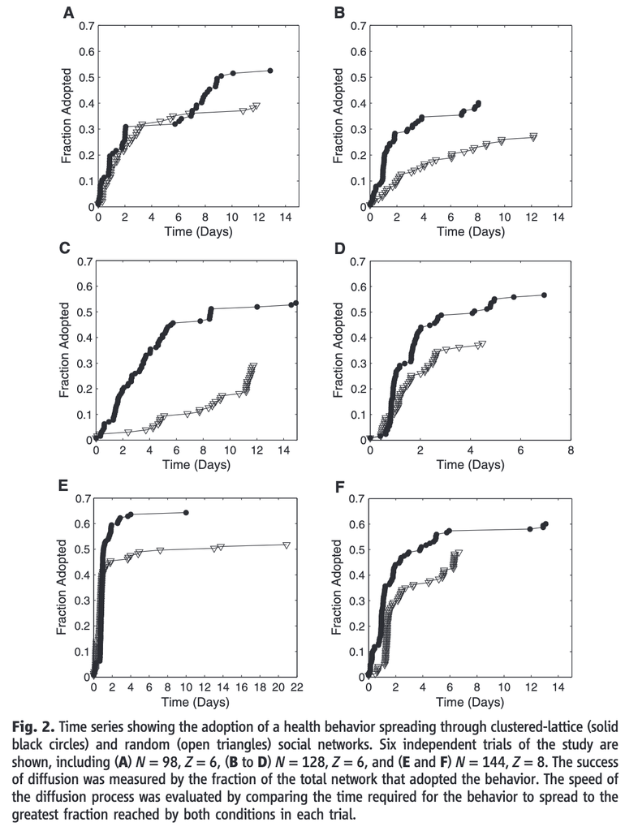

## Results

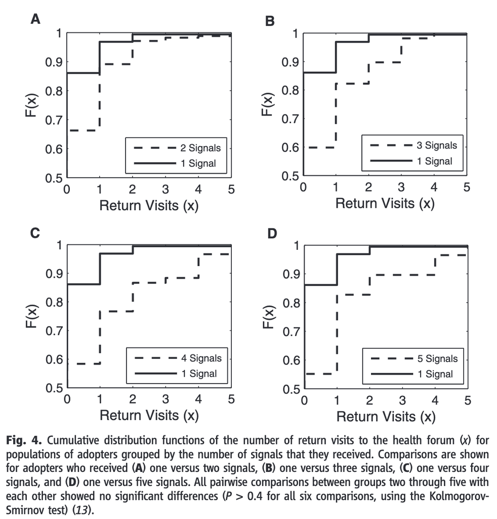

## Results

- Clustered networks more effective in spreading behaviour than weak networks
- On average, the behaviour reached 53.77% of the clustered networks, whereas only 38.26% of the population adopted in the random networks
- Adoption occurred more quickly in clustered networks, being about four times faster (!) than in random networks
- Neighbourhood size seems to matter as well: networks with a greater degree ($Z = 8$) performed better than those with a lower degree ($Z = 6$)
- Redundant signals significantly increased the likelihood of adoption too
- What do you make of these results?

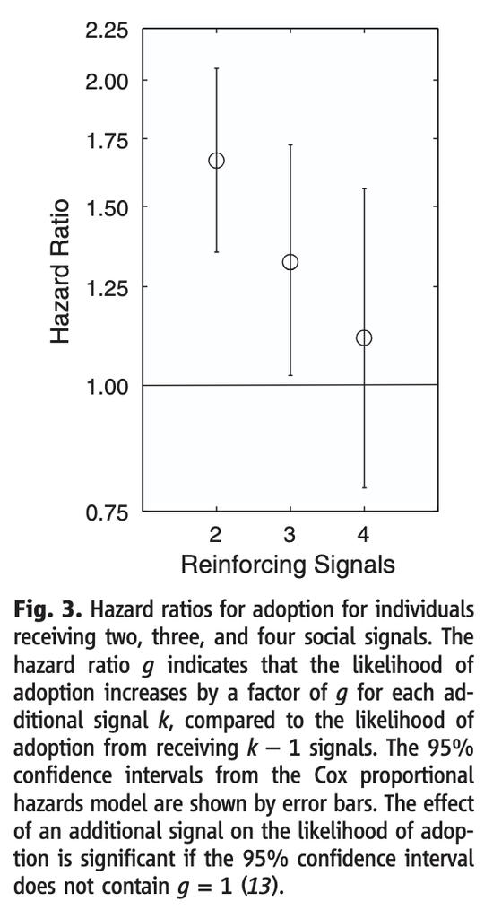

## Discussion

- The author concludes that clustered networks are more effective than random networks in spreading behaviour
- But there are some limitations to this study, too
- Can you think of any?
- Is the intervention realistic or relevant to real-world settings?
- What about interventions that cost money or effort to adopt (e.g., getting a screening, quitting smoking, exercising)?
- What do you think about his choice of not allowing participants to communicate with each other? Does it help reduce confounding or does it reduce external validity?
- What about ethical considerations of manipulating social networks, mainly when dealing with health behaviours?
- Can you think of policy implications?
- How can we use these findings to design better interventions for public health, marketing, or social change?
- How can we identify influential nodes in a network to maximise the spread of behaviour?

## Paluck et al. (2016)

### Changing climates of conflict: A social network experiment in 56 schools

- How can we change community-wide patterns of behaviour? (again!)
- Focus on adolescent school conflict - verbal/physical aggression, rumour-mongering, social exclusion
- Existing interventions target individual psychology (persuasion), mass education, or institutional regulation
- This study incorporates all three approaches:
  - Seed a social network with individuals demonstrating new behaviours
  - Rely on social influence to spread behaviour through network structures
  - Test whether this can shift overall school climate
- Key question: Can a small group of influential people shift a community’s behavioural climate?

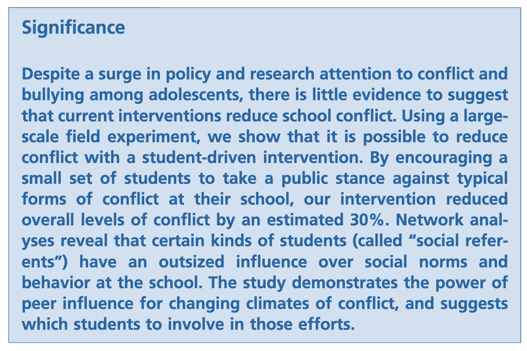

Source: [Paluck et al. (2016)](https://www.pnas.org/doi/abs/10.1073/pnas.1514483113)

## Motivation and research context

- There are heated debates about how social norms spread and change
  - Social norms: shared expectations about appropriate behaviour in a group
- Social norms emerge when they support the survival and functioning of groups, or because of arbitrary conventions
- Once in place, norms can be difficult to change
- Question: What mechanisms sustain social norms?
- Conformity pressures
- Fear of social sanctions
- Cognitive biases (status quo bias, loss aversion)
- Anything else?
- How are these ideas relevant to current debates on political polarisation, social integration, or public health behaviours (e.g., vaccination)?
- What role do “social referents” (influential individuals) play in norm change?

## Research design

- Multilevel experiment (we saw them last class!) across 56 New Jersey middle schools (24,191 students aged 11-15)
  - Randomised at school level (treatment vs. control)
  - Randomised at student level within treatment schools (seed students)
- Question: Which effects can we identify with this design?
- In the treatment schools, they selected 15% of the school population blocked by gender and grade to represent diverse social groups
- 50% of these students were randomly assigned to be “seeds” who would participate in the intervention activities
- Parents were informed and could opt their children out. Would you consider this ethical?
- Comprehensive measurement of school social networks before intervention
- “Who do you choose to spend time with?” - measures attention in network
  - What are the pros of this measure? Cons?
- Identified social referents - most connected students in each school
- Intervention: Anti-conflict campaign driven by seed students
- Encouraged public stance against conflict
- The outcome was measured via surveys and school disciplinary records
  - Why did they use both measures?

## Intervention details

- Grassroots campaign approach
- Seed students identified school-specific conflict behaviours
- Developed slogans and posters
- Distributed wristbands as rewards for positive behaviour
- No top-down, adult-defined problems: focused on student perspectives
- Standardised procedures with trained facilitators using scripts and activity guides
- High attendance at meetings (average >55% of invited students)
- Made meetings engaging: snacks, hands-on activities, technology

## Measures

- Outcomes measured subjectively and administratively
- Subjective: student-reported norms about conflict (pre/post surveys)
- Descriptive norms: how many students participate in conflict?
- Prescriptive norms: how many students disapprove of conflict?
- Administrative: school disciplinary records of peer conflict events (across the year)
- Focus on disciplinary events as a key behavioural outcome
- Arguably less susceptible to reporting bias than self-reported conflict

## Results

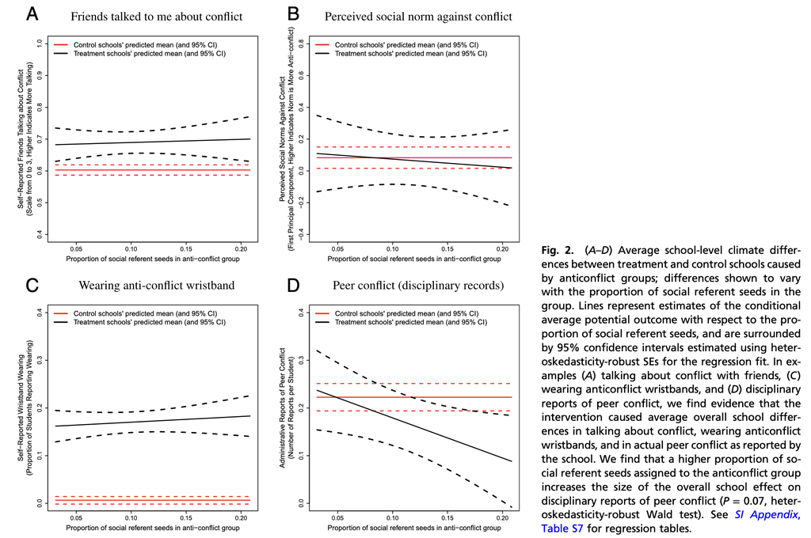

## Results

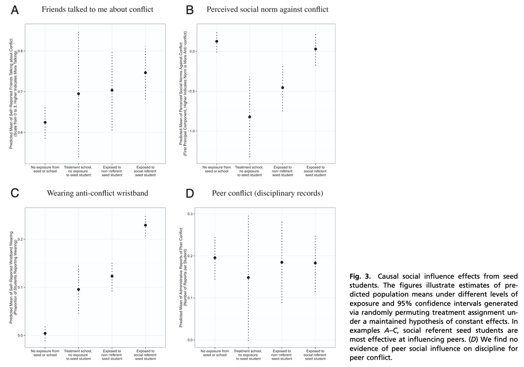

## Results

- Significant reduction in disciplinary reports in treatment schools ~30% reduction overall
- Effect stronger when seed groups contained more “social referent” students
- Increased talking about conflict reduction and wearing wristbands in treatment schools
- No average differences in social norms between treatment and control schools initially
- Social referent seeds were more influential than other seed students
  - 20% social referent seeds -> 60% reduction in disciplinary events
- Students exposed to social referent seeds more likely to:
  - Report friends discussing conflict reduction
  - Perceive stronger anti-conflict norms
  - Wear wristbands
- No peer-to-peer influence effect on discipline directly (climate-level effect stronger)

## Interpretation

- Intervention shifted school climate - widespread behavioural pattern
- Social referents key to norm and behaviour change
- Outsized influence due to attention from peers
- Not just structural position, but also traits and experiences
- Norms findings nuanced:
  - No overall shift in norms between schools
  - But within treatment schools, some norms did shift, especially via social referents
  - Possible “signal” effect of intervention - increased attention to conflict, leading to revised norm evaluations

## Implications

- Peer influence interventions can be effective in reducing school conflict
- Importance of social referents in changing behaviour
- Target these individuals in interventions for greater impact
- Highlights the usefulness of student-led initiatives
- Grassroots approach can be more effective than top-down
- Methodological contribution:
- Demonstrates rigorous social network experiment in real-world setting
- Multilevel randomisation for causal inference in networks

## Limitations

- What are some potential limitations of this study?
- Generalisability to other contexts? (different types of conflict, schools, cultures)
- Long-term effects?
- Mechanism of change fully understood?
- Reliance on disciplinary records - are these fully objective?
- Ethical considerations of network interventions? (manipulation of social structures?)
- What about the students who were not selected as “seeds” but were still part of the network? Were they affected negatively?

## Gerber and Green (2000)

### The effects of canvassing, telephone calls, and direct mail on voter turnout: A field experiment

- How effective are different get-out-the-vote (GOTV) tactics?
- Focus on three common methods:
  - Personal Canvassing (face-to-face)
  - Direct Mail (mailings)
  - Telephone Calls (phone banking)
- Context: Declining voter turnout in the US
  - Hypothesis: Decline linked to shift from personal to impersonal mobilisation
- Key Question: Is face-to-face canvassing more effective than impersonal methods in boosting voter turnout?

## Motivation and research context

- Voter turnout in US has declined over decades, with implications for democratic legitimacy
- Political campaigns increasingly rely on impersonal mobilisation methods (mail, phone) over personal canvassing
  - What are the pros and cons of each method?
  - Can this shift explain other trends in social engagement?
- Existing evidence mixed on effectiveness of different GOTV methods
- Do you believe that personal contact is more persuasive than impersonal methods? Why or why not?

## Research design

- Large-scale field experiment in New Haven, Connecticut (1998 election)
  - ~30,000 registered voters (~1/3 of the city’s population!)
  - Random assignment at household level to different GOTV treatments & control
- 2x2x4 Factorial Design:
  - Personal Canvassing
  - Telephone Calls
  - Direct Mail (None, One, Two, or Three mailings)
- Non-partisan messages used for all treatments
  - Civic duty, close election, neighbourhood solidarity appeals
- Outcome: Validated voter turnout from official records

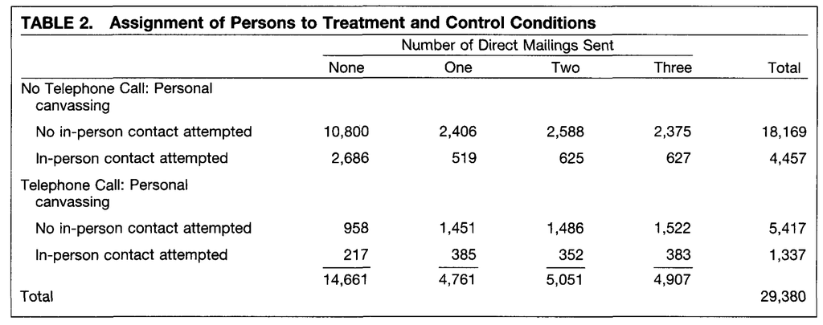

Source: [Gerber and Green (2000)](https://doi.org/10.2307/2585837)

## GOTV treatment details

- Personal Canvassing:
  - Paid canvassers (grad students) in pairs, weekends before election
  - Targeted specific households, not entire streets. Pros and cons?
  - Varied message appeals (civic duty, close election, neighbourhood solidarity)
  - Contact rate: ~28%
- Direct Mail:
  - Postcards designed by political consulting firm
  - Different texts for each appeal type
  - Varied number of mailings (1, 2, or 3) and message appeals
- Telephone Calls:
  - Out-of-state telemarketing firm, calls in days before election
  - Scripted calls, civic duty and close election appeals only
  - Contact rate: ~32% (reached household)

## Postcards

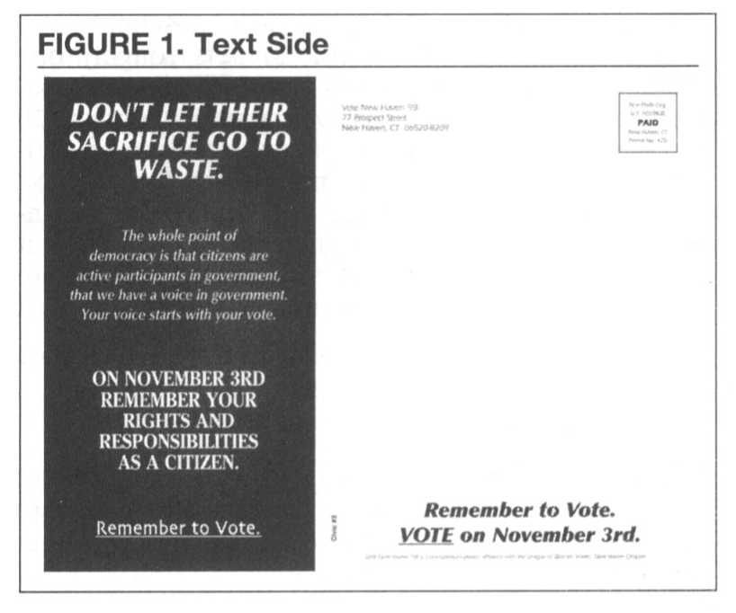

[figure not shown]

## Addressing contact rates - Instrumental variables

- Not everyone in treatment groups actually *received* treatment
  - Simply comparing contacted vs. non-contacted inflates effect
- Solution: Two-stage least squares (2SLS) regression using *intent-to-treat* as instrument
  - Instrument: Random assignment to treatment group (yes/no)
  - Endogenous variable: Actual contact (yes/no)
- Random assignment predicts contact, but is uncorrelated with other reasons for turnout (no direct effect on turnout except through treatment)
- Allows for causal estimation of treatment effect *accounting for* non-compliance (non-contact)

## Main effects

- Personal canvassing highly effective:
  - +8.7 percentage points increase in turnout (2SLS estimate)
  - ~9.8 points in multivariate model
  - Most effective GOTV method tested
- Direct mail shows small effect:
  - +0.6 points per mailing (multivariate model)
  - Small but statistically significant
  - Cumulative effect of 3 mailings ~ 2.5 points (probit)
- Telephone calls ineffective:
  - No significant effect, slight negative effect in some models
  - Despite professional firm and mirrored messaging

## Message and cost-effectiveness

- Message type mattered little for personal canvassing:
  - Civic duty, close election, neighbourhood solidarity appeals similarly effective (though close election slightly higher)
  - No significant interaction effects between treatments
- Cost-effectiveness analysis:
  - Personal canvassing: ~$8 per *additional* vote
  - Direct mail (3 mailings): ~$40 per *additional* vote
  - Face-to-face mobilisation significantly more cost-effective

## Interpretation

- Supports Hypothesis: Personal canvassing > impersonal methods for turnout
  - Decline in face-to-face mobilisation may contribute to turnout decline
- Unexpected Finding: Ineffectiveness of telephone calls
  - Despite professional execution & mirroring canvassing messages
  - Possible reasons: Routinised/scripted nature, out-of-state callers
- What are some possible mechanisms of personal canvassing effect?
- Speculation: Salience, memorability, connection, urgency… (future research needed)
- Study limitations? Can you identify some?
- Non-partisan messages, specific election context, short-term effects

## More limitations

- How about:
- Generalisability to other elections/contexts?
- Focus on *turnout* only - what about vote choice/persuasion?
- Short-term effects only - sustained impact?
- Specific message content - would different messages work better for mail/phone?
- Ethical considerations of GOTV experiments? (Manipulation of voters?)
- Hawthorne effect of canvassing? (People vote more because of the *attention*, not just the message)

# Conclusion

## Conclusion

- Centola (2010)
  - Showed *how* network structure (clustered vs. random) impacts spillovers
- Paluck et al. (2016)
  - Addressed interference by focusing on *network positions* (social referents) as key spillover agents
  - Multilevel design (school & student) managed school-level vs. peer-to-peer influence spillovers
- Gerber & Green (2000)
  - Demonstrated differential spillovers: face-to-face (strong), mail (weak), phone (none)
  - IV approach key to address interference from self-selection into contact, isolating *causal* effect
- Common thread: addressing interference
  - All three papers grapple with inherent dependencies in social settings (networks, communities, voter outreach)
  - Highlight the need for designs and analysis that account for, or exploit, these interdependencies
- Beyond “simple” experiments
  - Social science experiments increasingly move beyond simple treatment/control to address complex social interactions & spillovers
  - These examples show innovative designs for studying influence in interconnected systems

# And that’s all for today! 🎉